# Kruskal Wallis toets

NB Het peer review proces voor deze toets is nog niet afgerond; daarom is deze pagina nog in concept.

# 1 Toepassing

Gebruik de *Kruskal Wallis toets* om te toetsen of 2 of meer groepen significant van elkaar verschillen.[^1] De *Kruskal Wallis toets* kan een alternatief zijn voor de *one-way ANOVA*.[^2] De *Kruskal Wallis toets* stelt minder eisen aan de data en hoeft onder andere niet te voldoen aan de assumptie normaliteit. Bij de *Kruskal Wallis toets* hebben uitbijters minder invloed op het eindresultaat dan bij de *one-way ANOVA*. Daarentegen, als de data wel normaal verdeeld zijn, heeft de *Kruskal Wallis toets* minder onderscheidend vermogen dan de *one way ANOVA*.[^3]<sup>,</sup>[^4] Vandaar dat ondanks de voordelen er toch minder vaak voor de *Kruskal Wallis toets* test gekozen wordt.

# 2 Onderwijscasus

De opleidingsdirecteur van de tweejarige Masteropleiding Arbeidsrecht is geïnteresseerd in de afstudeersnelheid van zijn studenten. Hij vraagt zich af of er een verschil zit in het type vooropleiding die de studenten hebben gehaald en de hoeveel studiepunten die de studenten behalen in het eerste jaar. Hij kijkt naar de vier meest gangbare vooropleidingen die de studenten doorlopen voordat ze met de Master Arbeidsrecht beginnen: de Bachelors Fiscaal Recht, Notarieel Recht en Rechtsgeleerdheid en de Premaster.

*H<sub>0</sub>*: De verdeling van het aantal behaalde studiepunten in het eerste jaar van de maste Arbeidsrecht is gelijk voor studenten met als vooropleiding Bachelor Fiscaal Recht, Notarieel Recht of Rechtsgeleerdheid of de Premaster.

*H<sub>A</sub>*: De verdeling van het aantal behaalde studiepunten in het eerste jaar van de maste Arbeidsrecht is niet gelijk voor studenten met als vooropleiding Bachelor Fiscaal Recht, Notarieel Recht of Rechtsgeleerdheid of de Premaster.

# 3 Assumpties

Voor een valide resultaat moeten de data aan een aantal voorwaarden voldoen voordat de toets uitgevoerd kan worden: de data zijn (semi-)continu,[^5] de groepen zijn onafhankelijk van elkaar [^6] en het aantal groepen is groter dan 2. Gebruik bij 2 groepen de *Mann-Whitney U toets*.

# 4 Post-hoc toets

De *Kruskal Wallis toets* toetst of twee of meerdere groepen van elkaar verschillen. Een post-hoc toets specificeert welke groep significant van andere groepen verschillen. Gebruik de *Mann-Whitney U toets* als post-hoc toets.

Gebruik de *Bonferroni correctie* om Type I fouten te voorkomen. Deze correctie past de p-waarde aan door de p-waarde te vermenigvuldigen met het aantal uitgevoerde toetsen en verlaagt hiermee de kans dat er bij toeval een verband wordt ontdekt dat er niet is.[^7]<sup>,</sup>[^8]

# 5 Uitvoering

Er is een dataset ingeladen met studieresultaten van de master Arbeidsrecht per vooropleiding: Fiscaal Recht, Notarieel Recht, Rechtsgeleerdheid en de Premaster.

## 5.1 De data bekijken

Gebruik `head()` en `tail()` om de structuur van de data te bekijken.

```python
## Eerste 6 observaties
print(dfResultaten_Arbeidsrecht.head(6))
##    Studentnr      Vooropleiding  EC_Jaar1
## 0    3174851    Notarieel Recht      54.0
## 1    3499521  Rechtsgeleerdheid      36.0
## 2    3093697          Premaster      36.0
## 3    3170000      Fiscaal Recht      60.0
## 4    3199467    Notarieel Recht      54.0
## 5    3611663      Fiscaal Recht      30.0
```

```python
## Laatste 6 observaties
print(dfResultaten_Arbeidsrecht.tail(6))
##      Studentnr      Vooropleiding  EC_Jaar1
## 294    3652292          Premaster      42.0
## 295    3207419      Fiscaal Recht      60.0
## 296    3458278  Rechtsgeleerdheid      42.0
## 297    3863513  Rechtsgeleerdheid      54.0
## 298    3380456    Notarieel Recht      18.0
## 299    3293943          Premaster      60.0
```

De dataset bevat data van studenten van verschillende vooropleidingen. Gebruik `<data.frame>.<kolomnaam>.unique()` om te onderzoeken welke opleidingen er in de data aanwezig zijn.

```python
## Opleidingen in de data aanwezig
print(dfResultaten_Arbeidsrecht.Vooropleiding.unique())
```

```
## [Notarieel Recht, Rechtsgeleerdheid, Premaster, Fiscaal Recht]
## Categories (4, object): [Notarieel Recht, Rechtsgeleerdheid, Premaster, Fiscaal Recht]
```

Om meer inzicht te krijgen in de data, inspecteer de groepen met `length()`, `median()` en `quantile()`. Groepeer hiervoor eerst met `group_by()`.

```python
print(dfResultaten_Arbeidsrecht.groupby(['Vooropleiding']).size())
```

```
## Vooropleiding
## Fiscaal Recht        79
## Notarieel Recht      73
## Premaster            74
## Rechtsgeleerdheid    74
## dtype: int64
```

```python
print(dfResultaten_Arbeidsrecht.groupby(['Vooropleiding']).quantile([0.25, 0.5, 0.75]))
```

```
##                          Studentnr  EC_Jaar1
## Vooropleiding
## Fiscaal Recht     0.25  3337238.50      42.0
##                   0.50  3582707.00      54.0
##                   0.75  3795820.00      63.0
## Notarieel Recht   0.25  3291515.00      42.0
##                   0.50  3509887.00      54.0
##                   0.75  3725920.00      66.0
## Premaster         0.25  3172929.50      37.5
##                   0.50  3475862.50      48.0
##                   0.75  3786417.00      54.0
## Rechtsgeleerdheid 0.25  3170562.25      30.0
##                   0.50  3472624.50      42.0
##                   0.75  3708414.00      54.0
```

- Mediaan Fiscaal Recht: 54. *n* = 79.
- Mediaan Notarieel Recht: 54. *n* = 73.
- Mediaan Premaster: 48. *n* = 74.
- Mediaan Rechtsgeleerdheid: 42. *n* = 74.

### 5.1.1 Boxplot

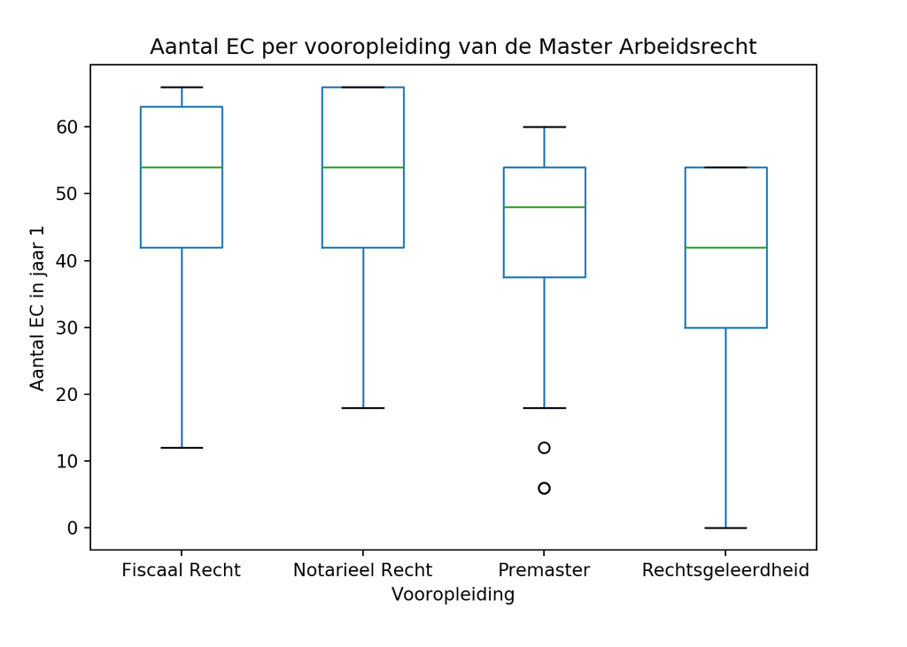

```python
import matplotlib.pyplot as plt
box = dfResultaten_Arbeidsrecht.boxplot(column='EC_Jaar1', by='Vooropleiding')
no_suptitle = plt.suptitle("")
title = plt.title("Aantal EC per vooropleiding van de Master Arbeidsrecht")
ylab = plt.ylabel("Aantal EC in jaar 1")
no_grid = plt.grid(b = False)
plt.show()
```

De mediaan van studenten met een vooropleiding Rechtsgeleerdheid heeft duidelijk minder studiepunten dan studenten met een vooropleiding Fiscaal Recht en Notarieel Recht. De studenten met de Premaster als vooropleiding ligt er tussen in.[^9]

## 5.2 Kruskal Wallis toets

Gebruik `stats.kruskal()` om de Kruskal-Wallis toets uit te voeren. Eerst moet de data worden gesplitst per opleiding. De standaard interpretatie van een statitische toets in Python is: `(<teststatistiek>, <p-waarde>)`. Verder toetst Python standaard tweezijdig.

```python
# We splitsen de dataset per opleiding
EC_FSC = dfResultaten_Arbeidsrecht[dfResultaten_Arbeidsrecht['Vooropleiding'] == "Fiscaal Recht"]["EC_Jaar1"]
EC_NTR = dfResultaten_Arbeidsrecht[dfResultaten_Arbeidsrecht['Vooropleiding'] == "Notarieel Recht"]["EC_Jaar1"]
EC_PRE = dfResultaten_Arbeidsrecht[dfResultaten_Arbeidsrecht['Vooropleiding'] == "Premaster"]["EC_Jaar1"]
EC_REC = dfResultaten_Arbeidsrecht[dfResultaten_Arbeidsrecht['Vooropleiding'] == "Rechtsgeleerdheid"]["EC_Jaar1"]
```

```python
import scipy.stats as stats
print(stats.kruskal(EC_FSC, EC_NTR, EC_PRE, EC_REC))
```

```
## KruskalResult(statistic=33.07301293995039, pvalue=3.1084596590622947e-07)
```

- *df*: het aantal groepen - 1 = 3
- *H*<sub>3</sub> = 33,07, p < 0,05
- De test-statistiek *H* volgt bij benadering de chi-kwadraat verdeling. Onder deze hypothese is *H* chi-kwadraat, vandaar dat dit in de output uitgedrukt wordt in chi-kwadraat
- p-waarde < 0,05, dus de H<sub>0</sub> wordt verworpen[^10]

## 5.3 Post-hoc toets: Mann-Whitney U toets

Gebruik de *Mann-Whitney U toets* als post-hoc toets om te bepalen wélke groepen significant verschillen. De *Mann-Whitney U toets* wordt ook wel de *Wilcoxon rank-sum toets* genoemd.[^11] Gebruik de functie `pg.mwu()`.

```python
import pingouin as pg
```

```python
# Correctie kan gedaan worden door p-value x aantal Hypotheses te doen (= 6)
pg.mwu(EC_PRE, EC_NTR)
```

```
##       U-val       tail     p-val    RBC   CLES
## MWU  1926.5  two-sided  0.002453  0.287  0.593
```

# 6 Rapportage

| Vooropleiding | N | Q1 | M | Q3 |
| --- | --- | --- | --- | --- |
| Fiscaal Recht | 79 | 42 | 54 | 63 |
| Notarieel Recht | 73 | 42 | 54 | 66 |
| Rechtsgeleerdheid | 74 | 30 | 42 | 54 |
| Premaster | 74 | 37,5 | 48 | 54 |

*Tabel 1. Groepsgrootte, 1e kwantiel, mediaan en 3e kwantiel per vooropleiding*

Deze pagina maakt onderdeel uit van het Statistisch Handboek Studiedata, ontwikkeld binnen de zone Veilig en betrouwbaar benutten van studiedata van het Versnellingsplan. R code is uitgevoerd met R versie 3.6.1; Python code is uitgevoerd in Python 3.7.  
© 2020 Versnellingsplan - Statistisch Handboek Studiedata. Laatst gewijzigd op: 12-02-2020

[^1]: De toets rangschikt de datapunten van laag naar hoog en geeft elke datapunt een rangnummer. Vervolgens wordt per groep het gemiddelde berekend van de rangnummers. Dit gemiddelde wordt met elkaar vergeleken. Voor meer informatie lees: Field, A., Miles, J., & Field, Z. (2012). *Discovering statistics using R*. London: Sage publications.
[^2]: Van Geloven, N. (21 maart 2018). *Kruskal Wallis*. [Wiki Statistiek Academisch Medisch Centrum](https://wikistatistiek.amc.nl/index.php/Kruskal_Wallis).
[^3]: Universiteit van Amsterdam (7 juli 2014). *Kruskal-Wallis Test*. [UvA Wiki Methodologiewinkel](https://wiki.uva.nl/methodologiewinkel/index.php/Kruskal-Wallis_Test).
[^4]: Onderscheidend vermogen: wordt in het Engels power genoemd, is de kans dat de nulhypothese verworpen wordt wanneer de alternatieve hypothese ‘waar’ is.
[^5]: Semi-continue data: de data zijn discreet, bijvoorbeeld gehele getallen, met zoveel mogelijkheden dat de data geanalyseerd kunnen worden alsof ze continu zijn. Van Geloven, N. (21 November 2017). *KEUZE TOETS*. [Wiki Statistiek Academisch Medisch Centrum](https://wikistatistiek.amc.nl/index.php/KEUZE_TOETS).
[^6]: Elke groep heeft geen overlap met één van de andere groepen en de groepen kunnen elkaars deelname niet beïnvloeden. Deze stap wordt beredeneerd en wordt niet getoetst.
[^7]: Type I fout: Ten onrechte H<sub>0</sub> verwerpen.
[^8]: Universiteit van Amsterdam (7 juli 2014). *Kruskal-Wallis Test*. [UvA Wiki Methodologiewinkel](https://wiki.uva.nl/methodologiewinkel/index.php/Kruskal-Wallis_Test).
[^9]: Bij niet normaal verdeelde data wordt de mediaan berekend in plaats van een gemiddelde om het midden van de data aan te geven.
[^10]: In dit voorbeeld wordt uitgegaan van een waarschijnlijkheid van 95% c.q. een p-waardegrens van 0,05. De grens is naar eigen inzicht aan te passen; houd hierbij rekening met Type I en Type II fouten.
[^11]: In dit voorbeeld wordt uitgegaan van een waarschijnlijkheid van 95% c.q. een p-waardegrens van 0,05. De grens is naar eigen inzicht aan te passen; houd hierbij rekening met Type I en Type II fouten.